# Assignment 3

Tejas Athni

11/07/2020

INTRODUCTION: This report highlights an urban data regression analysis that I perform to analyze the connection between veteran status and food stamp recipiency status with percentage of household income spent on gross rent, or alternatively, the percentage of the population who are cost-burdened with rent. This is a critical issue that has received much attention in the literature, and could shine much light on a crucial societal problem for the Bay Area.

SETUP: In this first chunk of code, I load the relevant libraries of interest and set the census key.

```r
library(tidyverse)
library(plotly)
library(sf)
library(tigris)
library(leaflet)
library(censusapi)
library(tidycensus)
library(corrplot)
library(dplyr)
Sys.setenv(CENSUS_KEY="0b20d8e27e52741cf293056779d3caf7e3793f0a")
setwd("E:/SynologyDrive/Tejas_Server/! Stanford University/! Year 3 - Quarter 1/PoliSci 218X/Assignment 3")
```

PUMS LEVEL ANALYSIS OF FOOD STAMPS AND VETERAN STATUS ON RENT BURDEN, 2018: According to U.S. Department of Housing and Urban Development, cost-burdened families are defined as those who “pay more than 30% of their income for housing.” In a November 2013 report published by the National Low Income Housing Coalition, it is highlighted that over 1.5 million households led by a veteran spend >50% of their income on housing, and for low-income veterans specifically this means that they are living on the edge of homelessness. These pieces of literature point toward the fact that veteran status and % of income spent on rent could be associated. Further, as it pertains to California specifically, the much higher cost of living is not accounted for when the federal government determines and allocates food stamp benefits. Thus, many organizations such as the Center on Budget and Policy Priorities believe that food stamp status and housing cost burden could be correlated.

Given the existing literature on the underlying interplays between veteran status (PUMS variable MIL), food stamp recipiency (PUMS variable FS), and cost-burdened status (PUMS variable GRPIP), I aimed to address the question of whether the food stamp recipiency status and veteran status in a given PUMA reliably predicts the percentage of household income consumed by gross rent in the past 12 months (continuous variable) through a regression analysis.

```r
census_api_key("0b20d8e27e52741cf293056779d3caf7e3793f0a")

ca_pums <- get_pums(
  variables = c(
    "PUMA",
    "GRPIP",
    "MIL",
    "FS"
  ),
  state = "CA",
  year = 2018,
  survey = "acs5",
  recode = T
)

ca_pumas <-
  pumas("CA", cb = T, progress_bar = F)
```

```r
bay_county_names <-
  c(
    "Alameda",
    "Contra Costa",
    "Marin",
    "Napa",
    "San Francisco",
    "San Mateo",
    "Santa Clara",
    "Solano",
    "Sonoma"
  )

bay_counties <-
  counties("CA", cb = T, progress_bar = F) %>%
  filter(NAME %in% bay_county_names)

bay_pumas <-
  ca_pumas %>%
  st_centroid() %>%
  .[bay_counties, ] %>%
  st_set_geometry(NULL) %>%
  left_join(ca_pumas %>% select(GEOID10)) %>%
  st_as_sf()

bay_pums <-
  ca_pums %>%
  filter(PUMA %in% bay_pumas$PUMACE10)


bay_pums_regression <-
  bay_pums %>%
  filter(SPORDER == 1) %>%
  mutate(
    foodstamps = ifelse(
      FS_label == "Yes",
      1,
      0
    )) %>%
  mutate(
    vet = ifelse(
      MIL_label == "On active duty in the past, but not now" |
        MIL_label == "Now on active duty",
      1,
      0
    ))


model_pums <- lm(GRPIP ~ foodstamps + vet, bay_pums_regression, weights = WGTP)

summary(model_pums)
```

```
##
## Call:
## lm(formula = GRPIP ~ foodstamps + vet, data = bay_pums_regression,
##     weights = WGTP)
##
## Weighted Residuals:
##     Min      1Q  Median      3Q     Max
## -442.62  -58.22  -45.10   10.77 1071.65
##
## Coefficients:
##             Estimate Std. Error t value Pr(>|t|)
## (Intercept) 15.03240    0.07136  210.65   <2e-16 ***
## foodstamps  24.71573    0.29234   84.55   <2e-16 ***
## vet         -4.27980    0.26864  -15.93   <2e-16 ***
## ---
## Signif. codes:  0 '***' 0.001 '**' 0.01 '*' 0.05 '.' 0.1 ' ' 1
##
## Residual standard error: 110.4 on 138436 degrees of freedom
## Multiple R-squared:  0.05125,    Adjusted R-squared:  0.05124
## F-statistic:  3739 on 2 and 138436 DF,  p-value: < 2.2e-16
```

DISCUSSION: From the results of the regression, I analyzed the Beta values for both the veteran status variable and the food stamp recipiency variable. It seems that with food stamp recipiency status, we see a roughly 24.7% increase in the percentage of household income that is consumed by gross rent. This predictor’s effect on the regression model is highly statistically significant with a p-value less than 2e-16. With veteran status, we see a roughly 4.3% decrease in the percentage of household income consumed by gross rent. This predictor’s effect on the regression model is also highly statistically significant with a p-value less than 2e-16. The y-intercept shows that with no food stamp recipiency and non-veteran status, gross rent makes up roughly 15% of the overall consumption of household income. Unfortunately, the adjusted R-squared for the model is quite low at 0.05, signifying that only 5% of the variance in the outcome variable is due to the input predictors, and thus a bad fit.

Regression analysis can never reveal causal relationships between variables of interest, and so my analysis does NOT support any causal claims. However, we do see a somewhat-clear association between food stamp recipiency and increased cost-burdening (which is concordant with the literature presented by the Center on Budget and Policy Priorities and in the general domain). Surprisingly, the veteran status actually seems to be inversely associated with cost-burdening, which is NOT what is observed in the literature.

ACS LEVEL ANALYSIS, 2018: To test my aforementioned question on a larger, more-ecological scale of analysis (to complement the PUMS analysis), I use the B25070 variable group in the ACS data for 2018. Due to slight variable and recorded data-style differences, I use percentages of veteran population and percentage of food stamp recipient population as my independent variables and % of rent-burdened households (>30% of income spent on gross rent) as the dependent variable. This ACS analysis is performed on the census tract level.

```r
pums_vars_2018 <-
  pums_variables %>%
  filter(year == 2018, survey == "acs5")

acs_vars_2018_5yr <-
  listCensusMetadata(
    name = "2018/acs/acs5",
    type = "variables"
  )
```

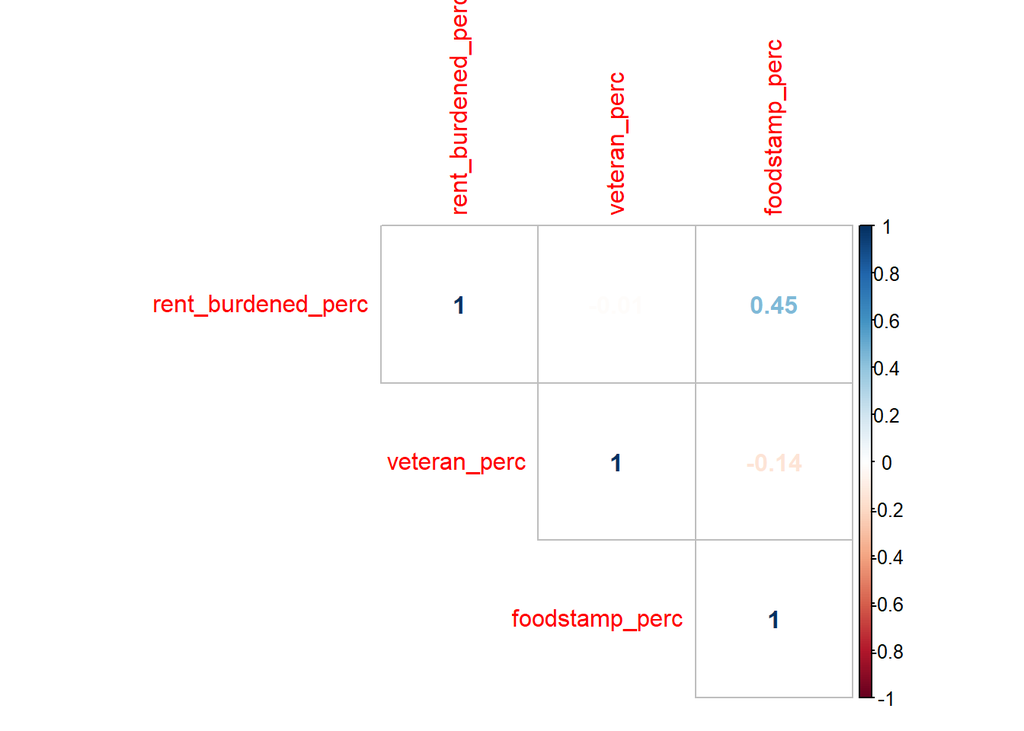

```r
bay_gross_rent_percent <-
  getCensus(
    name = "acs/acs5",
    vintage = 2018,
    region = "tract:*",
    regionin = "state:06+county:001,013,041,055,075,081,085,095,097",
    vars = c("B25070_001E",
             "B25070_007E",
             "B25070_008E",
             "B25070_009E",
             "B25070_010E")) %>%
  transmute(
    tract = paste0(state, county, tract),
    rent_burdened_perc = (B25070_007E + B25070_008E +
                            B25070_009E + B25070_010E) /
                            B25070_001E
  ) %>%
  filter(
    !is.na(rent_burdened_perc)
  )
bay_gross_rent_perc_df <- bay_gross_rent_percent


bay_veterans_count <-
  getCensus(
    name = "acs/acs5",
    vintage = 2018,
    region = "tract:*",
    regionin = "state:06+county:001,013,041,055,075,081,085,095,097",
    vars = c("B21001_001E",
             "B21001_002E")) %>%
  transmute(
    tract = paste0(state, county, tract),
    veteran_perc = B21001_002E / B21001_001E
  ) %>%
  filter(
    !is.na(veteran_perc)
  )
bay_veterans_count_df <- bay_veterans_count


bay_foodstamps <-
  getCensus(
    name = "acs/acs5",
    vintage = 2018,
    region = "tract:*",
    regionin = "state:06+county:001,013,041,055,075,081,085,095,097",
    vars = c("B22010_001E",
             "B22010_002E")) %>%
  transmute(
    tract = paste0(state, county, tract),
    foodstamp_perc = B22010_002E / B22010_001E
  ) %>%
  filter(
    !is.na(foodstamp_perc)
  )
bay_foodstamps_df <- bay_foodstamps


rent_vet_food <- left_join(bay_gross_rent_perc_df,
                           bay_veterans_count_df,
                           by = "tract")
rent_vet_food <- left_join(rent_vet_food,
                           bay_foodstamps_df,
                           by = "tract")

correlationplot <- rent_vet_food %>%
  select(
    rent_burdened_perc,
    veteran_perc,
    foodstamp_perc
  ) %>%
  cor()

corrplot(
  correlationplot,
  method = "number",
  type = "upper"
)
```

```r
model <- lm(rent_burdened_perc ~ foodstamp_perc + veteran_perc, rent_vet_food)

summary(model)
```

```
##
## Call:
## lm(formula = rent_burdened_perc ~ foodstamp_perc + veteran_perc,
##     data = rent_vet_food)
##
## Residuals:
##      Min       1Q   Median       3Q      Max
## -0.46393 -0.07741  0.00174  0.08127  0.61441
##
## Coefficients:
##                Estimate Std. Error t value Pr(>|t|)
## (Intercept)    0.379365   0.007288  52.054   <2e-16 ***
## foodstamp_perc 1.040537   0.052257  19.912   <2e-16 ***
## veteran_perc   0.253708   0.111532   2.275   0.0231 *
## ---
## Signif. codes:  0 '***' 0.001 '**' 0.01 '*' 0.05 '.' 0.1 ' ' 1
##
## Residual standard error: 0.1297 on 1572 degrees of freedom
## Multiple R-squared:  0.2016, Adjusted R-squared:  0.2006
## F-statistic: 198.4 on 2 and 1572 DF,  p-value: < 2.2e-16
```

This result is more concordant with the expected literature, that veteran status and food stamp recipiency are both positively predictive of the % of cost-burdened households. I re-iterate that this is no way a reflection of causation or anything close to causation; rather, this is purely an association with a suggested, built-in directionality.

DIFFERENT TIME PERIOD PUMS ANALYSIS FOR 2011: I went back in time 7 years earlier, and ran the analysis for 2011 as opposed to 2018. This analysis will shine light on whether a similar effect is seen across time.

```r
census_api_key("0b20d8e27e52741cf293056779d3caf7e3793f0a")

ca_pums <- get_pums(
  variables = c(
    "PUMA",
    "GRPIP",
    "MIL",
    "FS"
  ),
  state = "CA",
  year = 2011,
  survey = "acs5",
  recode = T
)

ca_pumas <-
  pumas("CA", cb = T, progress_bar = F)
```

```r
bay_county_names <-
  c(
    "Alameda",
    "Contra Costa",
    "Marin",
    "Napa",
    "San Francisco",
    "San Mateo",
    "Santa Clara",
    "Solano",
    "Sonoma"
  )

bay_counties <-
  counties("CA", cb = T, progress_bar = F) %>%
  filter(NAME %in% bay_county_names)

bay_pumas <-
  ca_pumas %>%
  st_centroid() %>%
  .[bay_counties, ] %>%
  st_set_geometry(NULL) %>%
  left_join(ca_pumas %>% select(GEOID10)) %>%
  st_as_sf()

bay_pumas$PUMACE10 <- str_remove(bay_pumas$PUMACE10, "^0+")

bay_pums <-
  ca_pums %>%
  filter(PUMA %in% bay_pumas$PUMACE10)


bay_pums_regression <-
  bay_pums %>%
  filter(SPORDER == 1) %>%
  mutate(
    foodstamps = ifelse(
      FS == 1,
      1,
      0
    )) %>%
  mutate(
    vet = ifelse(
      MIL == 1 | MIL == 2,
      1,
      0
    ))


model_pums <- lm(GRPIP ~ foodstamps + vet, bay_pums_regression, weights = WGTP)

summary(model_pums)
```

```
##
## Call:
## lm(formula = GRPIP ~ foodstamps + vet, data = bay_pums_regression,
##     weights = WGTP)
##
## Weighted Residuals:
##     Min      1Q  Median      3Q     Max
## -418.93  -65.80  -53.72   20.84  860.86
##
## Coefficients:
##             Estimate Std. Error t value Pr(>|t|)
## (Intercept)  16.9886     0.1596  106.45  < 2e-16 ***
## foodstamps   29.5588     0.6177   47.85  < 2e-16 ***
## vet           7.2610     0.9592    7.57 3.84e-14 ***
## ---
## Signif. codes:  0 '***' 0.001 '**' 0.01 '*' 0.05 '.' 0.1 ' ' 1
##
## Residual standard error: 119.6 on 31413 degrees of freedom
## Multiple R-squared:  0.0689, Adjusted R-squared:  0.06884
## F-statistic:  1162 on 2 and 31413 DF,  p-value: < 2.2e-16
```

DISCUSSION: With no food stamp recipiency and non-veteran status, we would expect that a household spends roughly 17% of their income on gross rent. Given food stamp recipiency status, we see a roughly 29.6% increase in the percentage of household income that is consumed by gross rent, tipping the percentage into “cost-burdened” territory. This predictor’s effect on the regression model is highly statistically significant with a p-value less than 2e-16. Given veteran status, we see a roughly 7.3% increase in the percentage of household income that is consumed by gross rent, just shy of the 30% cost-burdened threshold. This predictor’s effect on the regression model is highly statistically significant with a p-value of roughly 4e-14. The adjusted R-squared for the model is quite low at 0.0688, signifying that only about 7% of the variance in the outcome variable is due to the input predictors. Unlike the 2018 results, where we saw veteran status decreasing the percentage of income being spent on gross rent, the 2011 results seen here actually are more concordant with the trend observed in the literature, although not quite reaching the cost-burdened 30% threshold.

As compared to 2018, the 2011 trend seems to show a much stronger association for both predictor variables. However, once again, this does not show any sign of causation.

DIFFERENT TIME PERIOD ACS ANALYSIS FOR 2011: Next, I test if the large-scale ecological trend in 2011 is consistent with the micro-level PUMS analysis. If so, this would parallel the results found in the original 2018 analysis.

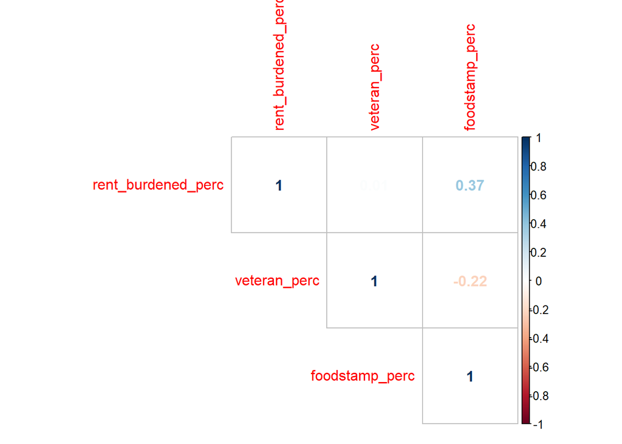

```r
bay_gross_rent_percent <-
  getCensus(
    name = "acs/acs5",
    vintage = 2011,
    region = "tract:*",
    regionin = "state:06+county:001,013,041,055,075,081,085,095,097",
    vars = c("B25070_001E",
             "B25070_007E",
             "B25070_008E",
             "B25070_009E",
             "B25070_010E")) %>%
  transmute(
    tract = paste0(state, county, tract),
    rent_burdened_perc = (B25070_007E + B25070_008E +
                            B25070_009E + B25070_010E) /
                            B25070_001E
  ) %>%
  filter(
    !is.na(rent_burdened_perc)
  )
bay_gross_rent_perc_df <- bay_gross_rent_percent


bay_veterans_count <-
  getCensus(
    name = "acs/acs5",
    vintage = 2011,
    region = "tract:*",
    regionin = "state:06+county:001,013,041,055,075,081,085,095,097",
    vars = c("B21001_001E",
             "B21001_002E")) %>%
  transmute(
    tract = paste0(state, county, tract),
    veteran_perc = B21001_002E / B21001_001E
  ) %>%
  filter(
    !is.na(veteran_perc)
  )
bay_veterans_count_df <- bay_veterans_count


bay_foodstamps <-
  getCensus(
    name = "acs/acs5",
    vintage = 2011,
    region = "tract:*",
    regionin = "state:06+county:001,013,041,055,075,081,085,095,097",
    vars = c("B19058_001E",
             "B19058_002E")) %>%
  transmute(
    tract = paste0(state, county, tract),
    foodstamp_perc = B19058_002E / B19058_001E
  ) %>%
  filter(
    !is.na(foodstamp_perc)
  )
bay_foodstamps_df <- bay_foodstamps


rent_vet_food <- left_join(bay_gross_rent_perc_df,
                           bay_veterans_count_df,
                           by = "tract")
rent_vet_food <- left_join(rent_vet_food,
                           bay_foodstamps_df,
                           by = "tract")

correlationplot <- rent_vet_food %>%
  select(
    rent_burdened_perc,
    veteran_perc,
    foodstamp_perc
  ) %>%
  cor()

corrplot(
  correlationplot,
  method = "number",
  type = "upper"
)
```

```r
model <- lm(rent_burdened_perc ~ foodstamp_perc + veteran_perc, rent_vet_food)

summary(model)
```

```
##
## Call:
## lm(formula = rent_burdened_perc ~ foodstamp_perc + veteran_perc,
##     data = rent_vet_food)
##
## Residuals:
##      Min       1Q   Median       3Q      Max
## -0.47178 -0.08441 -0.00151  0.08672  0.61836
##
## Coefficients:
##                Estimate Std. Error t value Pr(>|t|)
## (Intercept)    0.381637   0.009473  40.287  < 2e-16 ***
## foodstamp_perc 1.148430   0.069260  16.581  < 2e-16 ***
## veteran_perc   0.440059   0.105041   4.189 2.95e-05 ***
## ---
## Signif. codes:  0 '***' 0.001 '**' 0.01 '*' 0.05 '.' 0.1 ' ' 1
##
## Residual standard error: 0.1469 on 1573 degrees of freedom
## Multiple R-squared:  0.1489, Adjusted R-squared:  0.1478
## F-statistic: 137.6 on 2 and 1573 DF,  p-value: < 2.2e-16
```